# NBA Salary Prediction

Zefeng Cai

5/20/2021

## Abstract

#### The Purpose of the project is to build a model that predicts the salary for NBA player. Using Ordinary Least Square Regrssion method and theories, a multiple linear regression model is built with a range of features to predict the salary

```r
library(ggplot2)
library(car)
library(corrplot)
library(leaps)
library(ggcorrplot)
```

#### Read in data set

```r
train <- read.csv("NBATrain.csv")
test <- read.csv("NBATestNoY.csv")
```

## Data Preprocessing

#### First take a look at the training data set

```r
head(train)
```

```
##   Ob NBA_Country Age  TM  G   MP  PER   TS. X3PAr   FTr ORB. DRB. TRB. AST.
## 1  1         USA  30 TOT 70 1499  9.7 0.542 0.474 0.149  5.1 14.5  9.9  4.1
## 2  2         USA  23 DAL 30  472 16.2 0.558 0.010 0.267 11.0 29.1 19.8  6.3
## 3  3         USA  27 POR 70 2558 25.1 0.594 0.444 0.383  2.6 10.9  6.8 30.9
## 4  4         USA  26 TOT 20  422 13.5 0.539 0.482 0.372  1.5 10.1  5.7 26.7
## 5  5      Greece  23 MIL 73 2698 27.7 0.603 0.099 0.465  6.8 25.1 16.0 23.7
## 6  6         USA  25 POR 78 1432  9.3 0.535 0.542 0.113  2.6  9.0  5.8  8.9
##   STL. BLK. TOV. USG. OWS DWS   WS WS.48 OBPM DBPM  BPM VORP  Rk Pos GS   FG
## 1  1.2  1.4  8.1 11.5 1.0 1.2  2.2 0.071 -1.5 -0.1 -1.6  0.2 119  SF 24  4.2
## 2  3.3  4.1 18.1 13.8 0.4 1.0  1.3 0.137 -3.4  4.6  1.2  0.4 370   C  6  5.8
## 3  1.5  0.9 11.1 30.4 9.5 2.6 12.1 0.227  7.6 -0.8  6.8  5.7 298  PG 73 11.6
## 4  1.8  0.2 15.4 18.9 0.5 0.1  0.6 0.072  0.1 -2.5 -2.4  0.0  84  SG  0  0.0
## 5  1.9  3.3 11.6 31.3 8.6 3.5 12.1 0.214  4.2  1.8  5.9  5.4  16  PF 75 13.4
## 6  0.7  1.2  9.3 13.5 1.1 1.2  2.3 0.077 -0.9 -0.6 -1.5  0.2 107  SG  5  5.5
##    FGA   FG. X3P X3PA  X3P.  X2P X2PA  X2P.  FT  FTA    FT. ORB  DRB  TRB AST
```

[output cut: 27 more lines]

```r
tail(train)
```

```
##      Ob NBA_Country Age  TM  G   MP  PER   TS. X3PAr   FTr ORB. DRB. TRB. AST.
## 415 415         USA  27 GSW 66 2171 16.4 0.555 0.409 0.280  4.1 21.1 13.2 29.1
## 416 416         USA  32 NYK  7   40 15.6 0.510 0.000 0.400 16.7 22.1 19.4 14.0
## 417 417         USA  22 DEN 70 1366 18.0 0.589 0.398 0.267  4.5 23.8 14.2 10.1
## 418 418         USA  23 MIN 41  223  6.3 0.498 0.298 0.447  3.6  4.7  4.2  4.1
## 419 419         USA  28 NOP 78 2468 11.9 0.587 0.364 0.079  2.5  7.5  5.1 10.0
## 420 420         USA  23 ATL 23  395  6.2 0.467 0.239 0.248  2.3 15.8  9.1 14.1
##     STL. BLK. TOV. USG.  OWS DWS   WS  WS.48 OBPM DBPM  BPM VORP  Rk Pos GS  FG
## 415  2.0  3.2 21.8 17.1  2.8 3.4  6.2  0.138  0.6  2.9  3.5  3.0 187  PF 70 5.9
## 416  2.5  4.3 25.4 17.2  0.0 0.1  0.1  0.071 -2.3  3.3  1.0  0.0 369   C  0 6.2
## 417  1.1  2.1  9.0 21.2  2.6 1.2  3.8  0.133  0.6 -1.4 -0.8  0.4 308  PF  2 9.6
## 418  1.3  0.0  5.1 11.8  0.1 0.0  0.2  0.038 -2.0 -2.7 -4.7 -0.2 174  SG  0 4.7
## 419  1.5  0.4 10.7 16.2  2.4 1.5  3.9  0.075  0.5 -0.8 -0.4  1.0 349  SG 80 7.8
## 420  1.9  2.2 25.8 18.0 -0.9 0.4 -0.5 -0.060 -6.6  1.1 -5.5 -0.3  42  SF  3 5.7
##      FGA   FG. X3P X3PA  X3P. X2P X2PA  X2P.  FT FTA   FT. ORB  DRB  TRB  AST
```

[output cut: 27 more lines]

#### Check the dimension of the training data

```r
dim(train)
```

```
## [1] 420  68
```

#### Check if there is any duplicated observation, since each rows represents a unique player

```r
any(duplicated(train))
```

```
## [1] FALSE
```

#### Check if there is missing value in the data set. Since this is a in-class project, the NA/NULL values have been imputed.

```r
sum(is.null(train))
```

```
## [1] 0
```

```r
sum(is.na(train))
```

```
## [1] 0
```

#### Overview of the response/target: Salary

```r
summary(train$Salary)
```

```
##     Min.  1st Qu.   Median     Mean  3rd Qu.     Max.
##    65019  1982576  3771013  7227809  9532681 35439394
```

#### Show a histogram of ‘Salary’ to have a look at the distribution

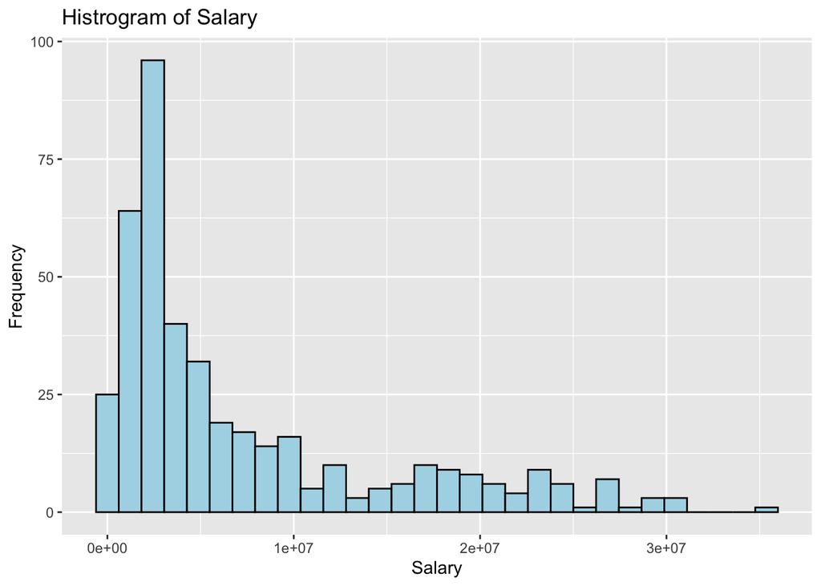

```r
ggplot(train, aes(x=Salary)) + geom_histogram(bins=30, color = 1, fill='light blue') + xlab("Salary") + ylab("Frequency") + ggtitle("Histrogram of Salary")
```

#### Take a look at the features names

```r
colnames(train)
```

```
##  [1] "Ob"          "NBA_Country" "Age"         "TM"          "G"
##  [6] "MP"          "PER"         "TS."         "X3PAr"       "FTr"
## [11] "ORB."        "DRB."        "TRB."        "AST."        "STL."
## [16] "BLK."        "TOV."        "USG."        "OWS"         "DWS"
## [21] "WS"          "WS.48"       "OBPM"        "DBPM"        "BPM"
## [26] "VORP"        "Rk"          "Pos"         "GS"          "FG"
## [31] "FGA"         "FG."         "X3P"         "X3PA"        "X3P."
## [36] "X2P"         "X2PA"        "X2P."        "FT"          "FTA"
## [41] "FT."         "ORB"         "DRB"         "TRB"         "AST"
## [46] "STL"         "BLK"         "TOV"         "PF"          "PTS"
## [51] "Ortg"        "DRtg"        "Team.Rk"     "Team"        "T.Conf"
## [56] "T.Div"       "T.W"         "T.L"         "T.W.L.PERC"  "T.MOV"
## [61] "T.Ortg"      "T.DRtg"      "NRtg"        "MOV.A"       "Ortg.A"
## [66] "DRtg.A"      "NRtg.A"      "Salary"
```

#### Construct correlation matrix using numeric feature

```r
correlate <- round(cor(train[unlist(sapply(train, class)) != 'character'], use = "pairwise.complete.obs"), 4)
sort(correlate[,"Salary"][abs(correlate[,"Salary"]) > 0.4], decreasing = TRUE)
```

```
## Salary     WS   VORP    OWS     GS    DWS     MP     FT    PTS    FTA     FG
## 1.0000 0.6464 0.6263 0.6118 0.5827 0.5708 0.5235 0.5190 0.4885 0.4776 0.4140
```

#### From the output above we can see there are 10 numeric features that have an absolute correlation with ‘Salary’; By Referencing the documentation, ‘WS’, ‘OWS’, ‘DWS’ are all measurement of win shares, while ‘OWS’ and ‘DWS’ specifically refer to ‘Offensive win share’ and ‘Defensive win share’. Hence, the more general and more correlated ‘WS’ will be used first, and ‘OWS’/‘DWS’ will be used as needed in the latter section. Similarly, ‘FT’ is ‘Free throw made’ and ‘FTA’ is ‘Free throw attampted’, the one with higher correlation will be used first.

#### Correlation heatmap is generated to investigate the correlation between features used above in order to reveal multicollinearity

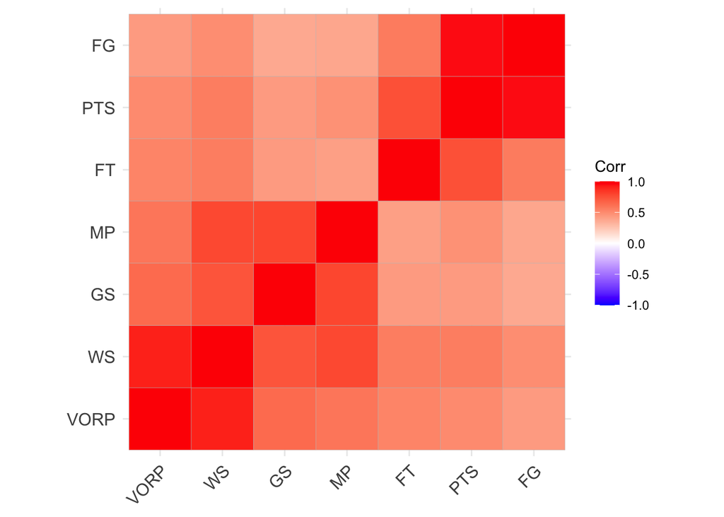

```r
num_relate <- round(cor(train[,c('VORP', 'WS','GS', 'MP', 'FT', 'PTS', 'FG')], use = "pairwise.complete.obs"),4)
ggcorrplot(num_relate)
```

#### As the heatmap show, there may be collinearity between ‘VORP’ and ‘WS’ also between ‘FG’ and ‘PTS’

## First attempt

#### Using only the 7 numeric features to build the first model

```r
m1 <- lm(Salary ~ WS + VORP + GS + MP + FT + PTS + FG, data = train)
summary(m1)
```

```
##
## Call:
## lm(formula = Salary ~ WS + VORP + GS + MP + FT + PTS + FG, data = train)
##
## Residuals:
##       Min        1Q    Median        3Q       Max
## -14142411  -3037202   -824883   2177796  20206004
##
## Coefficients:
##              Estimate Std. Error t value Pr(>|t|)
## (Intercept)  873406.8   858212.0   1.018   0.3094
## WS           343946.1   387633.4   0.887   0.3754
## VORP        1507593.2   656567.3   2.296   0.0222 *
## GS            69148.1    17522.4   3.946 9.33e-05 ***
## MP             -109.0      794.3  -0.137   0.8909
## FT           604603.8   288833.7   2.093   0.0369 *
## PTS          121355.1   202373.9   0.600   0.5491
## FG           -95063.9   432462.1  -0.220   0.8261
## ---
## Signif. codes:  0 '***' 0.001 '**' 0.01 '*' 0.05 '.' 0.1 ' ' 1
##
## Residual standard error: 5478000 on 412 degrees of freedom
## Multiple R-squared:  0.4885, Adjusted R-squared:  0.4798
## F-statistic: 56.21 on 7 and 412 DF,  p-value: < 2.2e-16
```

```r
vif(m1)
```

```
##        WS      VORP        GS        MP        FT       PTS        FG
## 14.754578  8.655143  3.135377  5.447560  4.543917 30.233877 19.361877
```

#### Using Variance inflation factor, we can confirm the collinearity between ‘WS’/‘VORP’ and ‘PTS’/‘FG’. Given ‘WS’ higher P-value, it may not be used in the next model.

#### As the output shown above, although most of the features have relatively high correlation with Salary, nearly half of them are statistically insignificant. However, since the NBA statisics are measured through out the career of the players, the data may misrepresents a player’s competence given one is in different stage of his career than others. Hence, some statistics are divided by ‘G’ which refer to games played and ‘Age’ will be also taken into the next model as it reflects an approximate stage a player’s in.

```r
train$minPerGame <- train$MP / train$G

train$ptPerGame <- train$PTS / train$G

train$FgPerGame <- train$FG / train$G
```

## Categorical features

#### Now we consider adding categorical feartures to the model.

```r
which(sapply(train, class) == 'character')
```

```
## NBA_Country          TM         Pos        Team      T.Conf       T.Div
##           2           4          28          54          55          56
```

```r
table(train$NBA_Country)
```

```
##
##        Australia           Canada          Croatia Democratic Re...
##                4                5                1                5
## Dominican Rep...            Egypt          Finland           France
##                1                1                2                8
##          Georgia          Germany           Greece           Israel
##                4                2                6                4
##            Italy        Lithuania             Mali      New Zealand
##                6                1                2                2
##      Puerto Rico           Russia          Senegal           Serbia
##                4                1                1                1
##      South Sudan            Spain      Switzerland          Tunisia
##                3                2                1                1
##           Turkey          Ukraine United Kingdo...              USA
##                4                2                2              344
```

```r
table(train$TM)
```

```
##
## ATL BOS BRK CHI CLE DAL DEN DET GSW HOU IND LAC LAL MEM MIA MIL MIN NOP NYK OKC
##  11  10  16   8   5  18  12  15  22  14   8   8  14  14   7  14  12  10  13  10
## ORL PHI POR SAC SAS TOT
##  12  19  10  11   8 119
```

```r
table(train$Pos)
```

```
##
##     C    PF    PG PG-SG    SF SF-SG    SG
##    75    77   100     1    71     4    92
```

```r
table(train$T.Conf)
```

```
##
##   E   W
## 226 194
```

```r
table(train$T.Div)
```

```
##
##   A   C  NW   P  SE  SW
## 126  68  51  62  32  81
```

#### First we categorized NBA_Country into two category, either USA or Non-USA as majority of players are from USA

```r
train$US_Country <- ifelse(train$NBA_Country == "USA", "USA", "Non_USA")
```

#### Then we categorize the players’ position into 3 main task.

```r
train$goal <- ifelse(((train$Pos == "SG") | (train$Pos == "SF")), "Score", ifelse(((train$Pos == "C") | (train$Pos == "PF")), "Defence", "Middle"))
```

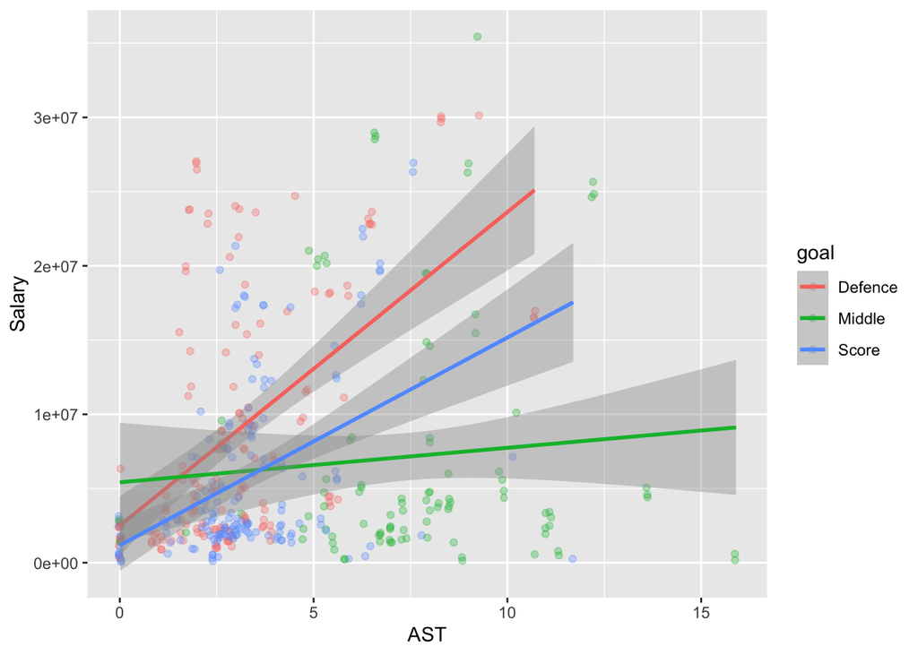

```r
ggplot(train, aes(x=AST, y = Salary, group = goal, color = goal)) + geom_point(alpha = 0.3, position = position_jitter()) + stat_smooth(method = "lm")
```

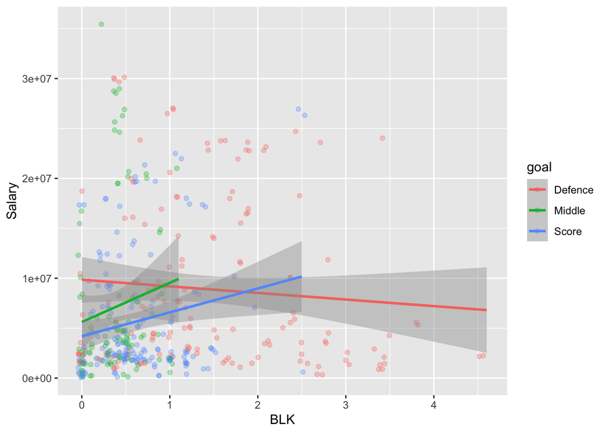

```r
ggplot(train, aes(x=BLK, y = Salary, group = goal, color = goal)) + geom_point(alpha = 0.3, position = position_jitter()) + stat_smooth(method = "lm")
```

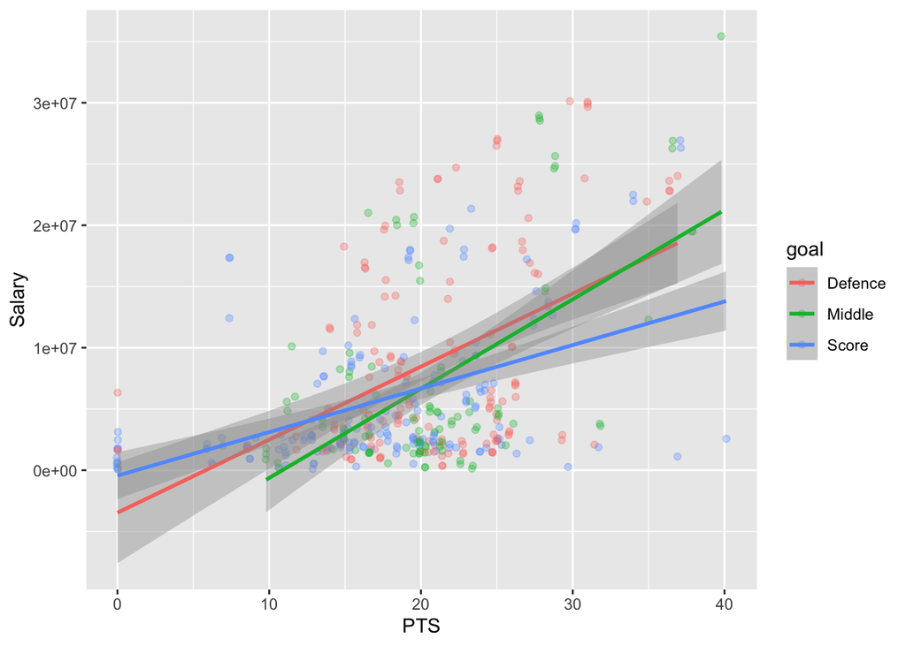

```r
ggplot(train, aes(x=PTS, y = Salary, group = goal, color = goal)) + geom_point(alpha = 0.3, position = position_jitter()) + stat_smooth(method = "lm")
```

#### The graphs above show, Some key basketball game statistic such as ‘PTS’–points, ‘BLK’–blocks, ‘AST’–Assist show a correlation between the player’s position in the game. Such interaction between features will be taken into consideration in building model, specifically the interaction between ‘AST’ and position.

#### Rank the average pay between difference teams

```r
sort(tapply(train$Salary, train$TM, mean))
```

```
##      DAL      DEN      CHI      MIA      ATL      PHI      DET      SAC
##  2603234  3889827  4192996  4921230  5042549  5134628  5310799  5460469
##      NOP      BRK      ORL      NYK      BOS      TOT      CLE      SAS
##  5575611  5610724  5803428  6515755  6811163  7019450  8219170  8263279
##      GSW      LAL      MIN      POR      IND      MIL      LAC      HOU
##  8371636  8676504  8777972  9072419  9333285  9675639 10912244 11548655
##      MEM      OKC
## 12092245 14079327
```

#### Using boxplot to visualize the difference between average pay across teams

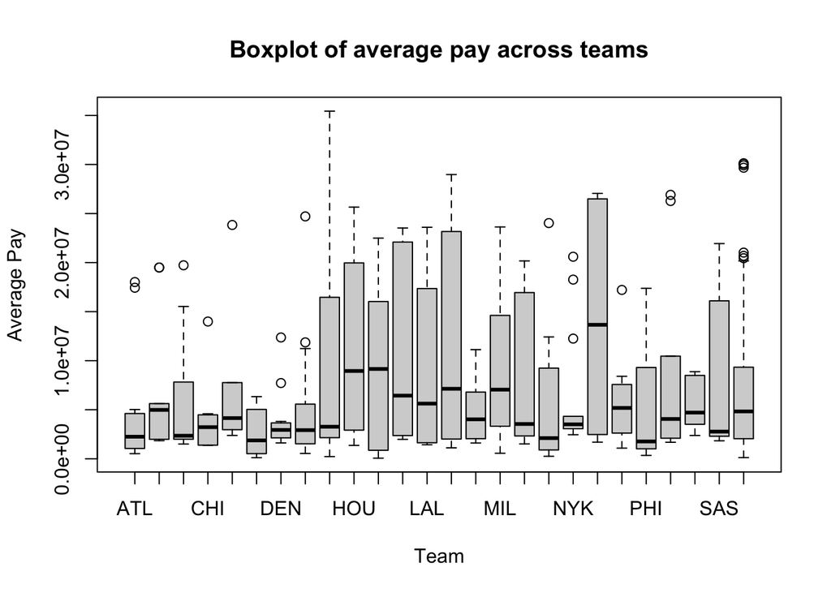

```r
boxplot(Salary ~ TM, data = train, xlab="Team", ylab = "Average Pay", main = "Boxplot of average pay across teams")
```

#### From the boxplot above we can see distinct difference in pay across teams; plot the average pay in ascending order

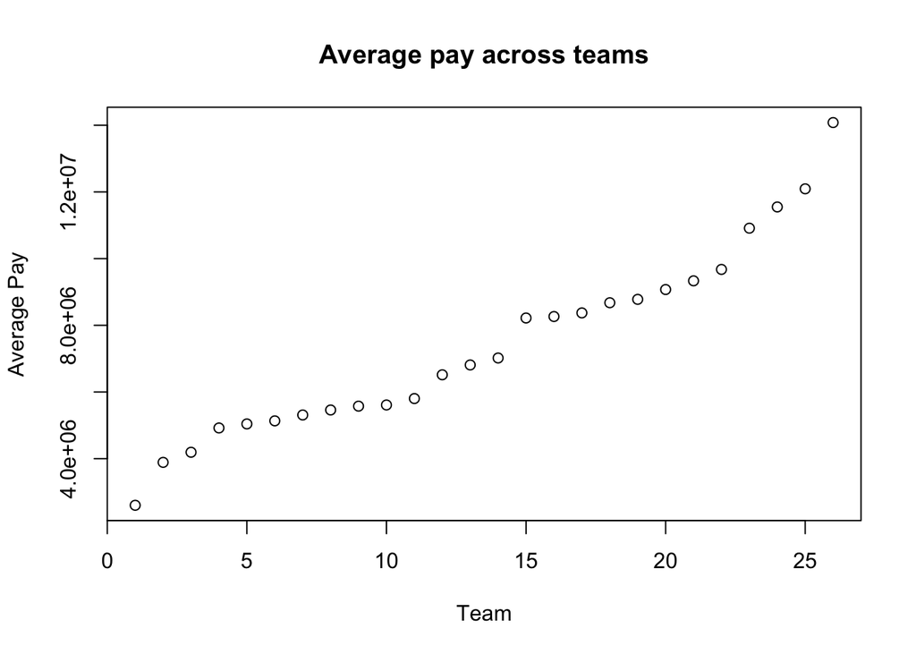

```r
plot(sort(tapply(train$Salary, train$TM, mean)), xlab="Team", ylab = "Average Pay", main = "Average pay across teams")
```

#### As shown above, there are obvious gaps between certain level of average pay; several tiers are made accordingly.

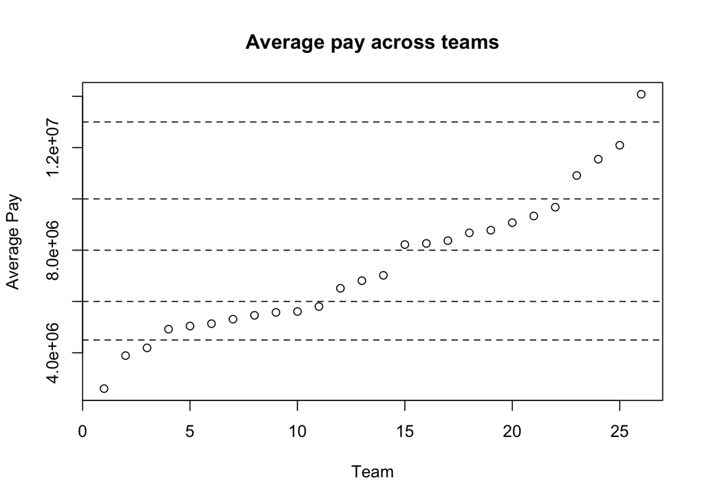

```r
plot(sort(tapply(train$Salary, train$TM, mean)), xlab="Team", ylab = "Average Pay", main = "Average pay across teams")
abline(h = 13000000, lty = 2)
abline(h = 10000000, lty = 2)
abline(h = 8000000, lty = 2)
abline(h = 6000000, lty = 2)
abline(h = 4500000, lty = 2)
```

#### Rank the average pay in different tiers

```r
train$cash_reserve <- ifelse(train$TM == "OKC", "first",
                    ifelse(train$TM == "MEM"|train$TM == "HOU"|train$TM == "LAC", "second",
                    ifelse(train$TM == "MIL"|train$TM == "IND"|train$TM == "POR"|train$TM == "MIN"|
                             train$TM == "LAL"|train$TM == "GSW"|train$TM == "SAS"|train$TM == "CLE", "third",
                    ifelse(train$TM == "TOT"|train$TM == "BOS"|train$TM == "NYK", "fourth",
                    ifelse(train$TM == "DAL"|train$TM == "DEN"|train$TM == "CHI", "sixth", "fifth")))))
```

## Second Attempt

#### The second model building includes the transformed variable ‘minPerGame’/‘ptPerGame’/‘FgPerGame’ that better reflects the game statistics and Age as mentioned before, also the categorical variable ‘cash_reserve’ and interaction effect ‘AST:goal’ shown above.

```r
m2 <- lm(Salary ~ VORP + GS + minPerGame + FT + ptPerGame + FgPerGame + Age + cash_reserve + AST:goal, data = train)
summary(m2)
```

```
##
## Call:
## lm(formula = Salary ~ VORP + GS + minPerGame + FT + ptPerGame +
##     FgPerGame + Age + cash_reserve + AST:goal, data = train)
##
## Residuals:
##       Min        1Q    Median        3Q       Max
## -11934314  -2660899   -287623   2018527  15632733
##
## Coefficients:
##                     Estimate Std. Error t value Pr(>|t|)
## (Intercept)        -11546394    1603324  -7.202 2.93e-12 ***
## VORP                 1801210     291537   6.178 1.58e-09 ***
## GS                     17878      15370   1.163 0.245449
## minPerGame            241397      47563   5.075 5.91e-07 ***
## FT                    671020     172625   3.887 0.000119 ***
## ptPerGame            -371882     298664  -1.245 0.213798
## FgPerGame            1284142     688756   1.864 0.062985 .
## Age                   368189      54880   6.709 6.64e-11 ***
## cash_reservefirst    6533147    1627615   4.014 7.12e-05 ***
## cash_reservefourth   1323110     654626   2.021 0.043921 *
## cash_reservesecond   1790631     966824   1.852 0.064744 .
## cash_reservesixth   -1847751     912934  -2.024 0.043631 *
## cash_reservethird     457409     711561   0.643 0.520702
## AST:goalDefence       459824     174433   2.636 0.008710 **
## AST:goalMiddle        -85876      89198  -0.963 0.336248
## AST:goalScore        -151204     174878  -0.865 0.387759
## ---
## Signif. codes:  0 '***' 0.001 '**' 0.01 '*' 0.05 '.' 0.1 ' ' 1
##
## Residual standard error: 4740000 on 404 degrees of freedom
## Multiple R-squared:  0.6244, Adjusted R-squared:  0.6104
## F-statistic: 44.77 on 15 and 404 DF,  p-value: < 2.2e-16
```

#### As the output shown above, ‘GS’ is not significant, and transformation of ‘MP’ and ‘FG’ contribute more to the model as before. Before making any conclusion, the assumption of linear regression model will be verified first.

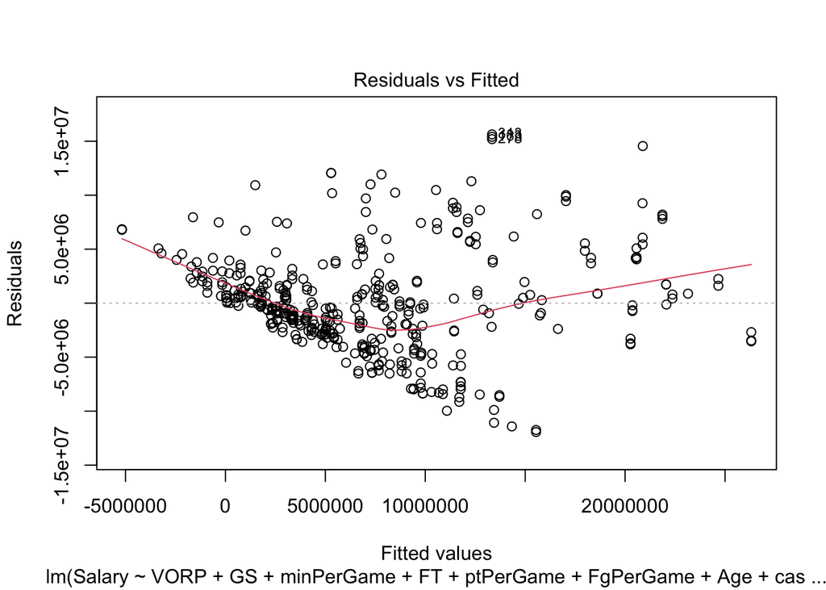

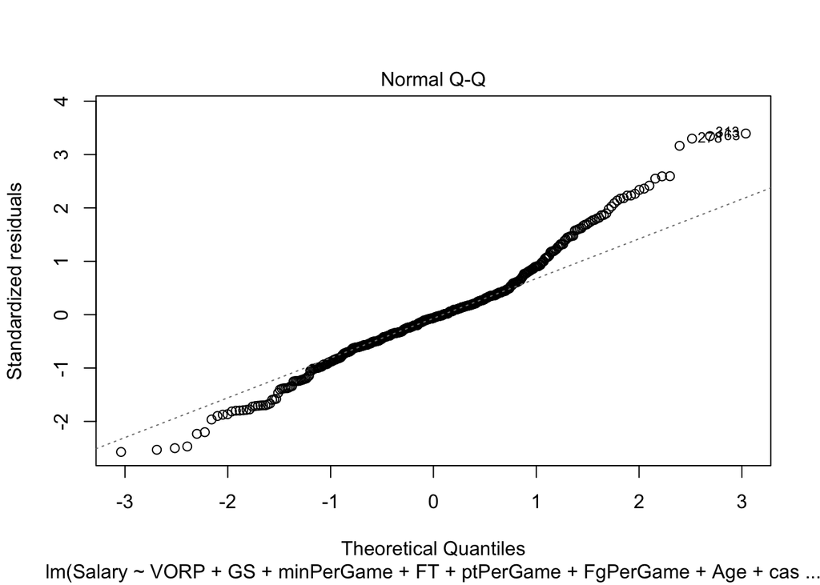

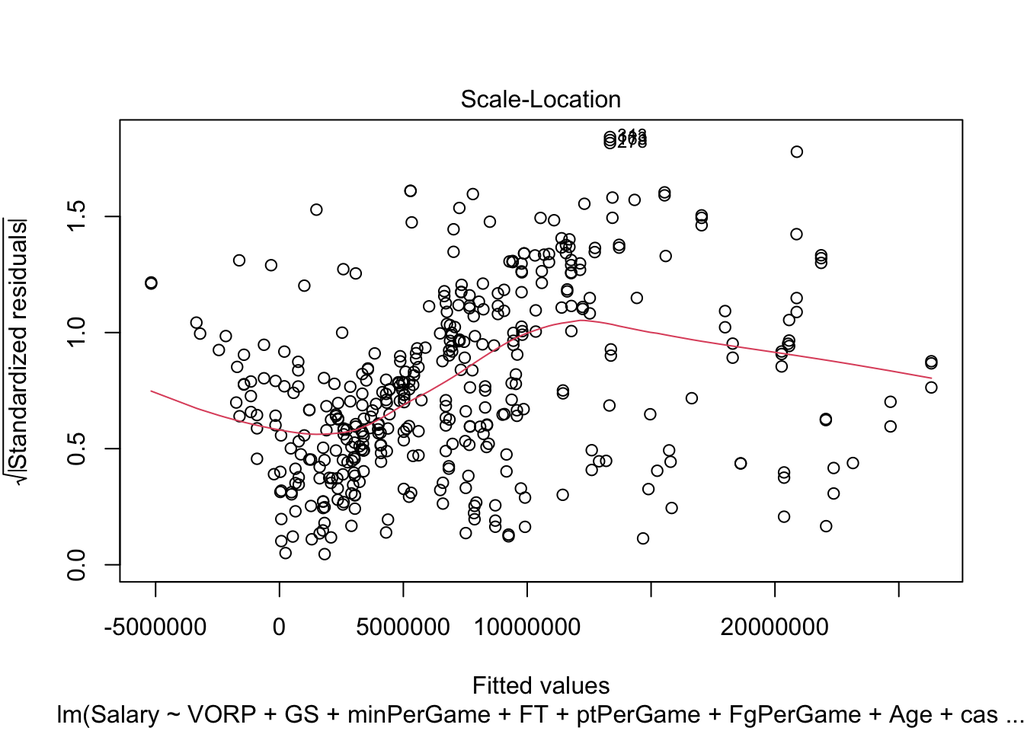

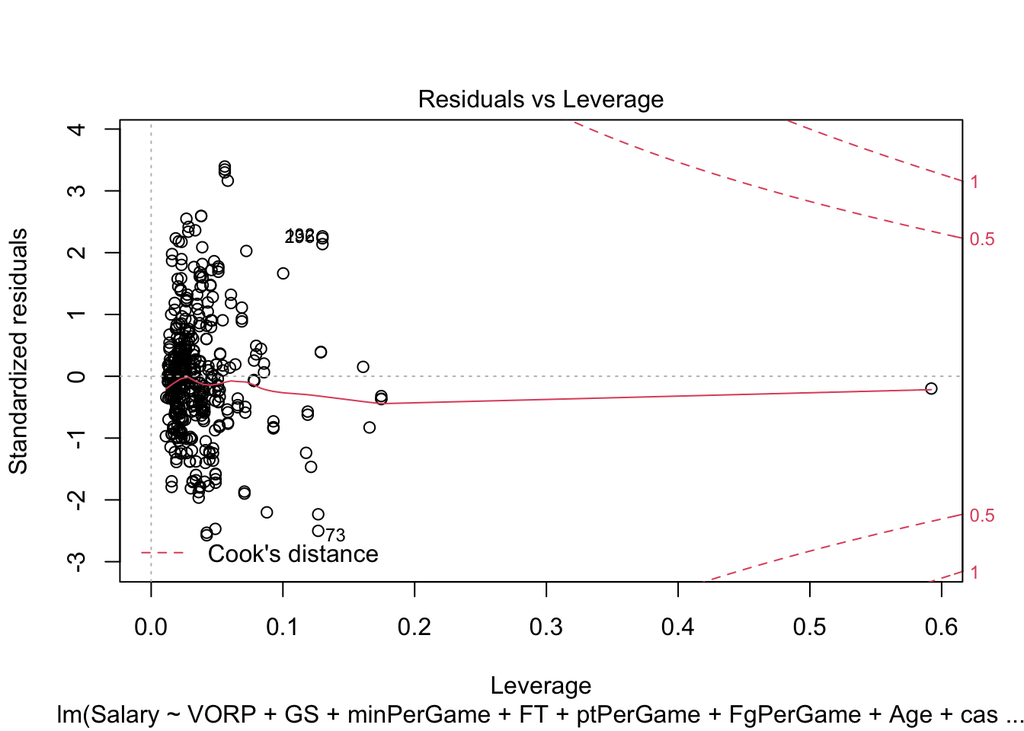

```r
plot(m2)
```

#### As the diagnostic plot above shown that although there’s no data point that exceeds the Cook Distance which classify them as outlier, the constant variance and normality assumption of the model is slightly violated. A numerical transformation is needed.

#### Before using PowerTransform, the 0 value in the variable needed to be imputed with adding 0.001 since the function requires strictly positive value.

```r
train$FT[train$FT == 0] = 0.001
train$FgPerGame[train$FgPerGame == 0] = 0.001
train$GS[train$GS == 0] = 0.001
train$ptPerGame[train$ptPerGame == 0] = 0.001
train$minPerGame[train$minPerGame == 0] = 0.001
```

```r
summary(powerTransform(cbind(GS, minPerGame, FT, ptPerGame, FgPerGame, Age) ~ 1, data = train))
```

```
## bcPower Transformations to Multinormality
##            Est Power Rounded Pwr Wald Lwr Bnd Wald Upr Bnd
## GS            0.1990        0.20       0.1717       0.2263
## minPerGame    0.8443        0.84       0.7170       0.9716
## FT            0.5129        0.50       0.4616       0.5643
## ptPerGame     0.1370        0.14       0.1125       0.1616
## FgPerGame     0.1402        0.14       0.1125       0.1679
## Age          -0.5759       -1.00      -1.1336      -0.0182
##
## Likelihood ratio test that transformation parameters are equal to 0
##  (all log transformations)
##                                      LRT df       pval
## LR test, lambda = (0 0 0 0 0 0) 1039.823  6 < 2.22e-16
##
## Likelihood ratio test that no transformations are needed
##                                      LRT df       pval
## LR test, lambda = (1 1 1 1 1 1) 4988.434  6 < 2.22e-16
```

## Third Attempt

#### Using the transformed variable above:

```r
train$GS <- train$GS ^ 0.2
train$minPerGame <- train$minPerGame ^ 0.84
train$FT <- sqrt(train$FT)
train$ptPerGame <- train$ptPerGame ^ 0.14
train$FgPerGame <- train$FgPerGame ^ 0.14
train$Age <- train$Age ^ (-1)
```

```r
m3 <- lm(Salary ~ VORP + GS + minPerGame + FT + ptPerGame + FgPerGame + Age + cash_reserve + AST:goal, data = train)
summary(m3)
```

```
##
## Call:
## lm(formula = Salary ~ VORP + GS + minPerGame + FT + ptPerGame +
##     FgPerGame + Age + cash_reserve + AST:goal, data = train)
##
## Residuals:
##       Min        1Q    Median        3Q       Max
## -12653159  -3001109   -312248   2377340  15644213
##
## Coefficients:
##                      Estimate Std. Error t value Pr(>|t|)
## (Intercept)           3618176    2257116   1.603   0.1097
## VORP                  2288437     261358   8.756  < 2e-16 ***
## GS                    -816307     563542  -1.449   0.1482
## minPerGame             649588      97994   6.629 1.09e-10 ***
## FT                     628600     489792   1.283   0.2001
## ptPerGame             -813246    5800613  -0.140   0.8886
## FgPerGame             6965247    6527854   1.067   0.2866
## Age                -272857084   39750894  -6.864 2.53e-11 ***
## cash_reservefirst     7366271    1619234   4.549 7.13e-06 ***
## cash_reservefourth    1223556     671935   1.821   0.0694 .
## cash_reservesecond    1818640     970550   1.874   0.0617 .
## cash_reservesixth    -1714719     929575  -1.845   0.0658 .
## cash_reservethird     1005743     716306   1.404   0.1611
## AST:goalDefence        374931     177828   2.108   0.0356 *
## AST:goalMiddle        -113768      90702  -1.254   0.2105
## AST:goalScore         -305472     178748  -1.709   0.0882 .
## ---
## Signif. codes:  0 '***' 0.001 '**' 0.01 '*' 0.05 '.' 0.1 ' ' 1
##
## Residual standard error: 4782000 on 404 degrees of freedom
## Multiple R-squared:  0.6178, Adjusted R-squared:  0.6036
## F-statistic: 43.53 on 15 and 404 DF,  p-value: < 2.2e-16
```

```r
vif(m3)
```

```
##                   GVIF Df GVIF^(1/(2*Df))
## VORP          1.799806  1        1.341568
## GS            3.512665  1        1.874211
## minPerGame    4.353408  1        2.086482
## FT            2.001624  1        1.414787
## ptPerGame    19.854575  1        4.455847
## FgPerGame    18.942340  1        4.352280
## Age           1.132300  1        1.064096
## cash_reserve  1.633416  5        1.050291
## AST:goal      1.892466  3        1.112170
```

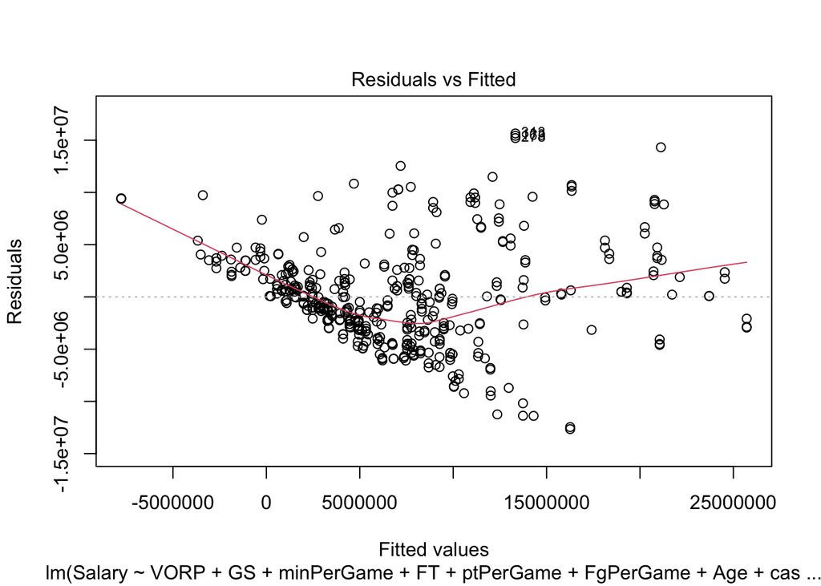

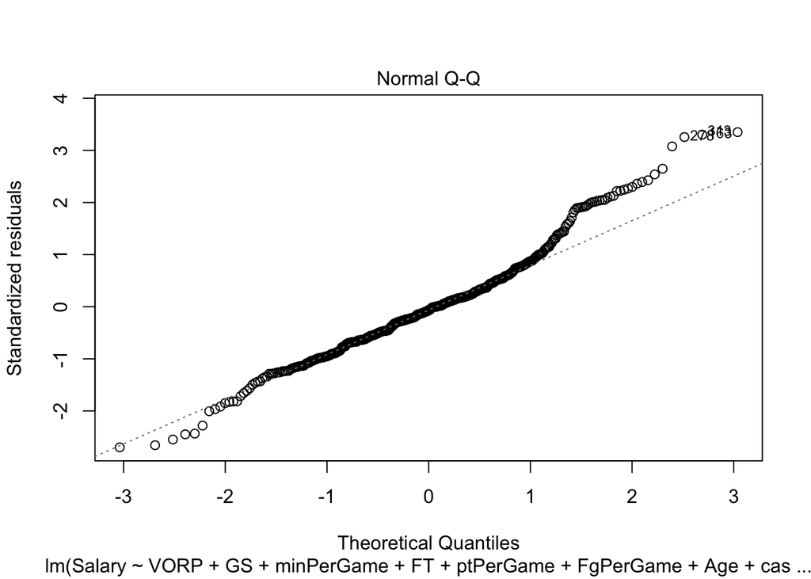

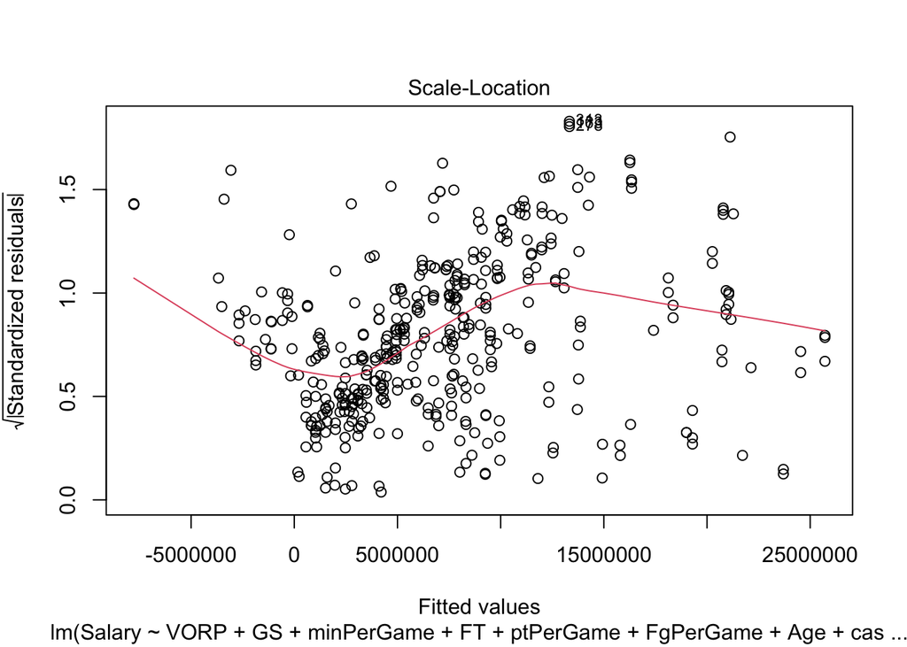

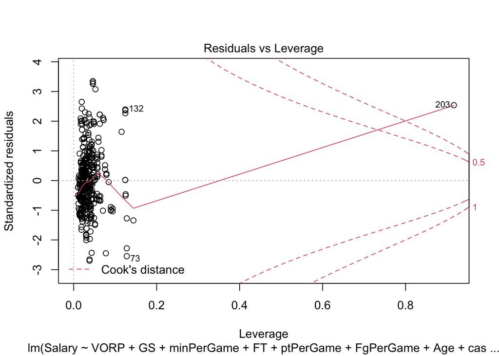

```r
plot(m3)
```

#### Using backward BIC to determine if there’s any variable worth taking out.

```r
backm3 <- step(m3, direction = "backward", data = train, k = log(420))
```

```
## Start:  AIC=12999.79
## Salary ~ VORP + GS + minPerGame + FT + ptPerGame + FgPerGame +
##     Age + cash_reserve + AST:goal
##
##                Df  Sum of Sq        RSS   AIC
## - ptPerGame     1 4.4943e+11 9.2377e+15 12994
## - FgPerGame     1 2.6031e+13 9.2633e+15 12995
## - FT            1 3.7661e+13 9.2749e+15 12996
## - GS            1 4.7975e+13 9.2853e+15 12996
## <none>                       9.2373e+15 13000
## - cash_reserve  5 7.4721e+14 9.9845e+15 13002
## - AST:goal      3 5.0688e+14 9.7442e+15 13004
## - minPerGame    1 1.0047e+15 1.0242e+16 13037
## - Age           1 1.0773e+15 1.0315e+16 13040
## - VORP          1 1.7530e+15 1.0990e+16 13067
##
## Step:  AIC=12993.77
## Salary ~ VORP + GS + minPerGame + FT + FgPerGame + Age + cash_reserve +
##     AST:goal
##
##                Df  Sum of Sq        RSS   AIC
## - FT            1 4.1076e+13 9.2788e+15 12990
## - GS            1 4.7581e+13 9.2853e+15 12990
## <none>                       9.2377e+15 12994
## - cash_reserve  5 7.5972e+14 9.9975e+15 12997
## - AST:goal      3 5.2542e+14 9.7632e+15 12999
## - FgPerGame     1 2.9534e+14 9.5331e+15 13001
## - minPerGame    1 1.0125e+15 1.0250e+16 13031
## - Age           1 1.0780e+15 1.0316e+16 13034
## - VORP          1 1.7651e+15 1.1003e+16 13061
##
## Step:  AIC=12989.59
## Salary ~ VORP + GS + minPerGame + FgPerGame + Age + cash_reserve +
##     AST:goal
##
##                Df  Sum of Sq        RSS   AIC
## - GS            1 4.6216e+13 9.3250e+15 12986
## <none>                       9.2788e+15 12990
## - cash_reserve  5 7.8190e+14 1.0061e+16 12993
## - AST:goal      3 5.5019e+14 9.8290e+15 12996
## - FgPerGame     1 3.4500e+14 9.6238e+15 12999
## - Age           1 1.0806e+15 1.0359e+16 13030
## - minPerGame    1 1.2003e+15 1.0479e+16 13035
## - VORP          1 1.8534e+15 1.1132e+16 13060
##
## Step:  AIC=12985.64
## Salary ~ VORP + minPerGame + FgPerGame + Age + cash_reserve +
##     AST:goal
##
##                Df  Sum of Sq        RSS   AIC
## <none>                       9.3250e+15 12986
## - cash_reserve  5 7.7088e+14 1.0096e+16 12989
## - AST:goal      3 5.2002e+14 9.8450e+15 12990
## - FgPerGame     1 4.1524e+14 9.7403e+15 12998
## - Age           1 1.0597e+15 1.0385e+16 13025
## - VORP          1 1.8364e+15 1.1161e+16 13055
## - minPerGame    1 1.8553e+15 1.1180e+16 13056
```

```r
train <- train[-c(278, 313, 163, 203),]
```

## Final Attempt

```r
m4 <- lm(Salary ~ VORP + minPerGame  + ptPerGame + FgPerGame + Age + cash_reserve + AST:goal, data = train)
summary(m4)
```

```
##
## Call:
## lm(formula = Salary ~ VORP + minPerGame + ptPerGame + FgPerGame +
##     Age + cash_reserve + AST:goal, data = train)
##
## Residuals:
##       Min        1Q    Median        3Q       Max
## -11094590  -2633488   -298141   2317113  15030454
##
## Coefficients:
##                      Estimate Std. Error t value Pr(>|t|)
## (Intercept)           3475259    2161013   1.608  0.10858
## VORP                  2483992     250526   9.915  < 2e-16 ***
## minPerGame             568655      68666   8.281 1.83e-15 ***
## ptPerGame           -18841568   13432190  -1.403  0.16147
## FgPerGame            27744215   15632193   1.775  0.07669 .
## Age                -261343776   38154883  -6.850 2.79e-11 ***
## cash_reservefirst     7221163    1545150   4.673 4.05e-06 ***
## cash_reservefourth    1362558     629003   2.166  0.03088 *
## cash_reservesecond     498193     948640   0.525  0.59976
## cash_reservesixth    -1875948     889717  -2.108  0.03561 *
## cash_reservethird      682967     683713   0.999  0.31844
## AST:goalDefence        458511     168042   2.729  0.00664 **
## AST:goalMiddle         -78953      85788  -0.920  0.35796
## AST:goalScore         -195481     170412  -1.147  0.25202
## ---
## Signif. codes:  0 '***' 0.001 '**' 0.01 '*' 0.05 '.' 0.1 ' ' 1
##
## Residual standard error: 4568000 on 402 degrees of freedom
## Multiple R-squared:  0.6308, Adjusted R-squared:  0.6189
## F-statistic: 52.84 on 13 and 402 DF,  p-value: < 2.2e-16
```

## Test Data

```r
any(duplicated(test))
```

```
## [1] FALSE
```

```r
test$US_Country <- ifelse(test$NBA_Country == "USA", "USA", "Non_USA")
test$minPerGame <- test$MP / test$G
test$ptPerGame <- test$PTS / test$G
test$FgPerGame <- test$FG / test$G

test$goal <- ifelse(((test$Pos == "SG") | (test$Pos == "SF")), "Score", ifelse(((test$Pos == "C") | (test$Pos == "PF")), "Defence", "Middle"))

test$cash_reserve <- ifelse(test$TM == "OKC", "first",
                    ifelse(test$TM == "MEM"|test$TM == "HOU"|test$TM == "LAC", "second",
                    ifelse(test$TM == "MIL"|test$TM == "IND"|test$TM == "POR"|test$TM == "MIN"|
                             test$TM == "LAL"|test$TM == "GSW"|test$TM == "SAS"|test$TM == "CLE", "third",
                    ifelse(test$TM == "TOT"|test$TM == "BOS"|test$TM == "NYK", "fourth",
                    ifelse(test$TM == "DAL"|test$TM == "DEN"|test$TM == "CHI", "sixth", "fifth")))))

test$FT[test$FT == 0] = 0.001
test$FgPerGame[test$FgPerGame == 0] = 0.001
test$GS[test$GS == 0] = 0.001
test$ptPerGame[test$ptPerGame == 0] = 0.001
test$minPerGame[test$minPerGame == 0] = 0.001

train$GS <- train$GS ^ 0.2
train$minPerGame <- train$minPerGame ^ 0.84
train$FT <- sqrt(train$FT)
train$ptPerGame <- train$ptPerGame ^ 0.14
train$FgPerGame <- train$FgPerGame ^ 0.14
train$Age <- train$Age ^ (-1)
```

```r
result <- as.matrix(predict(m4, newdata = test))
final <- cbind(test[,1],result)
```

#### The result is submitted to kaggle for evaluation using the salary predicted by the model.